# Praca Domowa I

Skoro przeglądamy zależności to może pora przestać bawic się w detektywa a wziąć ciekawe dane z macierzy korelacji i to właśnie je pokazać.

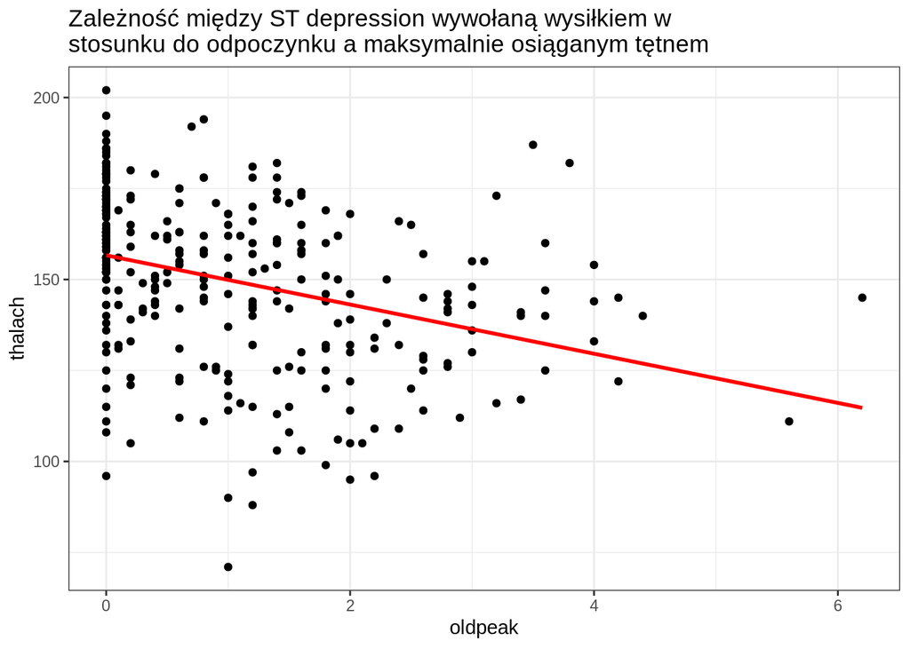

```r
ggplot(data, aes(oldpeak, thalach))+
  geom_point() +
  geom_smooth(method="lm", color="red", se=FALSE) +
  labs(title = "Zależność między ST depression wywołaną wysiłkiem w \nstosunku do odpoczynku a maksymalnie osiąganym tętnem") +
  theme_bw()
```

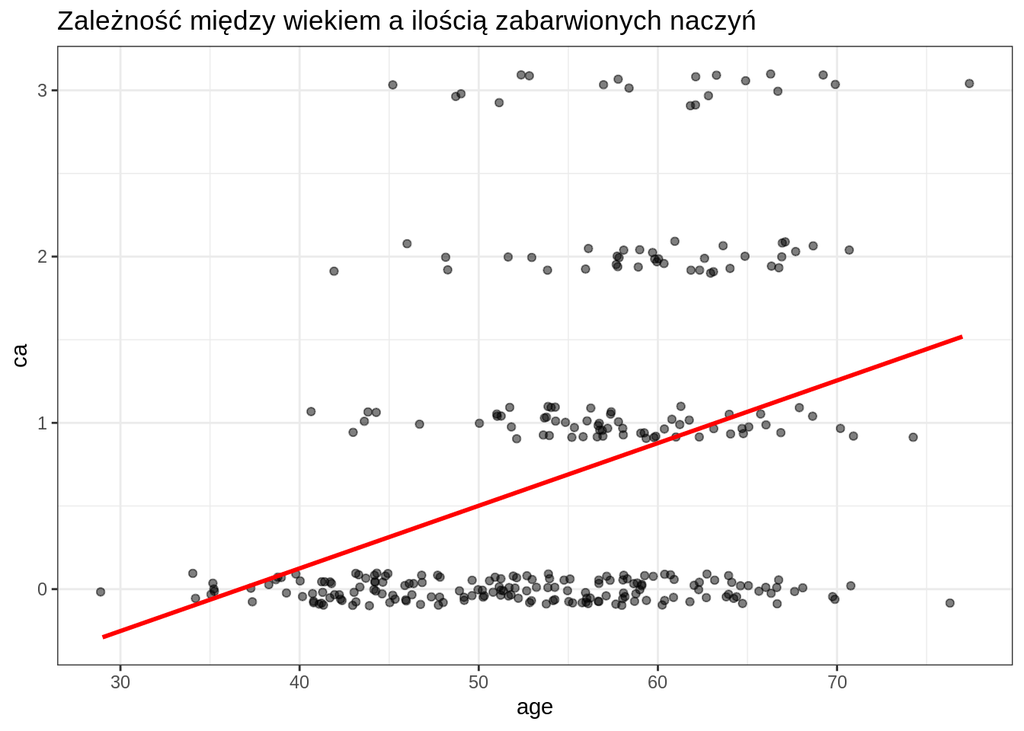

```r
ggplot(data, aes(age, ca))+
  geom_point(position =  position_jitter(h = 0.1), alpha = 0.5) +
  geom_smooth(method="lm", color="red", se=FALSE) +
  labs(title = "Zależność między wiekiem a ilością zabarwionych naczyń") +
  theme_bw()
```

Dwa powyższe wykresy pokazują już jakąś korelację zmiennych (odpowiednio ujemną i dodatnią) o których wydaje mi się, że zostało już powiedziane. Tytuły i znajomość medycznych określeń samodzielnie tłumaczą wykres. Aby nie rozpisywać się - jak widać, tętno maleje przy ST depression, a osoby w starszym wieku mają wieksze szanse na nowotwór (albo inne schorzenia wykryte przy RTG). Musimy jednak pamiętać, że jeśli chodzi o wiek, to większość pacjentów była w wieku ponad 50, więc ilość danych do młodych osób jest nieporównywalna i nie wiadomo czy oni mniej chorowali i dlatego ich nie ma w danych, więc można z tego założyć, że starci mają więcej problemów zdrowotnych z sercem, albo może byli leczeni w innym miejscu. Każda analiza stawia kolejne ciekawe pytania do których można szukać odpowiedzi.

Podsumowując, można badać więcej zależności i ciekawostek, które znajdują się w zbiorze, jednak w tej pracy domowej zostały przedstawione jedynie przykłady analizy i wyodrębnione aspekty. Swiadomie nie zajęliśmy się wartościami NA, było ich tylko 6, teoretycznie można było je uzupełnić medianą, albo wykorzystać inny sposób ML, lecz na wzgląd na mała ilość tych danych pozostwione zostały w spokoju.